# Density extrapolation: model progression

**Progress:** upper velocity gave the largest improvement, quality fields added further gains, and total reflectivity (`dbz_all`) added a small increment. All models use **6.6/6.6 VID thresholds**, **1,446,106 training profiles**, and **20,682,097 training rows**, with unchanged target sampling and evaluation rows. Density remains the prediction target.

| Model | Cumulative additions | Inputs | Selected rounds |
| --- | --- | --- | --- |
| Baseline | Density shape, target gap/AGL, location, seasonal/night-time terms and upper VID | 38 | 5,585 |
| + u/v | Upper-layer horizontal velocity components | 96 | 12,107 |
| + quality | Upper-layer `sd_vvp`, `n_dbz`, angular `gap` flag | 183 | 19,920 |
| + dbz_all | Upper-layer total reflectivity | 212 | 19,875 |

Each added field has 29 upper-only slots. Missing values stay missing; hidden lower layers are excluded. The `dbz_all` fit early-stopped at **20,175 rounds**, below its **30,000** ceiling; earlier fits had 20,000-round ceilings.

## Mean error across 100–500 m

| Evaluation | Baseline | + u/v | + quality | + dbz_all |
| --- | --- | --- | --- | --- |
| Historical reporting | 64.704 | 59.901 | 58.065 | 58.018 |
| Held-out year (2025) | 65.597 | 60.884 | 58.646 | 58.374 |
| Held-out sites | 68.222 | 65.095 | 62.324 | 62.058 |
| Held-out sites + year | 68.923 | 65.955 | 62.779 | 62.540 |

Arithmetic mean of the five depth-specific RMSE values, in birds/km³. Historical = separate nights at familiar sites; year = 2025; sites = 21 excluded radars; sites + year = those radars in 2025. These are evaluation scores, not the stopping-validation preview.

Against the u/v model, quality fields reduced mean RMSE by **3.1–4.8%** across the four evaluations. Adding `dbz_all` then reduced it by **0.08–0.46%**. The gains are descriptive, not significance tests.

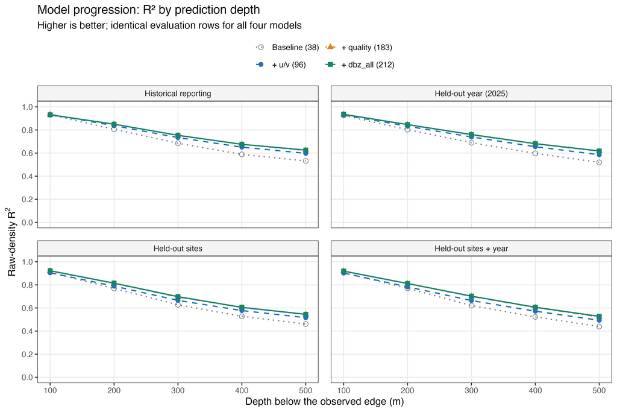

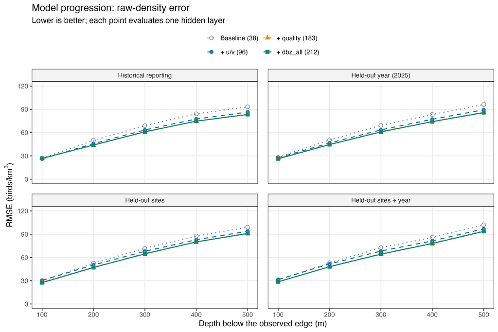

## Depth-specific scores

### Historical reporting

R² / RMSE (birds/km³). Each depth scores one hidden layer.

| Depth (m) | Baseline | + u/v | + quality | + dbz_all |
| --- | --- | --- | --- | --- |
| 100 | 0.9312 / 26.88 | 0.9349 / 26.14 | 0.9320 / 26.72 | 0.9315 / 26.80 |
| 200 | 0.8062 / 50.05 | 0.8375 / 45.84 | 0.8513 / 43.84 | 0.8500 / 44.03 |
| 300 | 0.6855 / 69.00 | 0.7342 / 63.44 | 0.7521 / 61.26 | 0.7541 / 61.02 |
| 400 | 0.5887 / 84.27 | 0.6512 / 77.60 | 0.6768 / 74.71 | 0.6756 / 74.84 |
| 500 | 0.5318 / 93.32 | 0.5978 / 86.49 | 0.6224 / 83.80 | 0.6260 / 83.40 |

### Held-out year (2025)

R² / RMSE (birds/km³). Each depth scores one hidden layer.

| Depth (m) | Baseline | + u/v | + quality | + dbz_all |
| --- | --- | --- | --- | --- |
| 100 | 0.9264 / 28.21 | 0.9297 / 27.56 | 0.9340 / 26.71 | 0.9360 / 26.29 |
| 200 | 0.8026 / 50.67 | 0.8327 / 46.64 | 0.8457 / 44.79 | 0.8469 / 44.62 |
| 300 | 0.6895 / 69.42 | 0.7395 / 63.58 | 0.7579 / 61.29 | 0.7606 / 60.95 |
| 400 | 0.5974 / 83.39 | 0.6549 / 77.22 | 0.6802 / 74.33 | 0.6815 / 74.17 |
| 500 | 0.5196 / 96.30 | 0.5856 / 89.43 | 0.6159 / 86.11 | 0.6184 / 85.83 |

### Held-out sites

R² / RMSE (birds/km³). Each depth scores one hidden layer.

| Depth (m) | Baseline | + u/v | + quality | + dbz_all |
| --- | --- | --- | --- | --- |
| 100 | 0.9078 / 30.03 | 0.9050 / 30.48 | 0.9205 / 27.88 | 0.9227 / 27.49 |
| 200 | 0.7691 / 52.63 | 0.7889 / 50.32 | 0.8130 / 47.37 | 0.8151 / 47.10 |
| 300 | 0.6276 / 71.81 | 0.6660 / 68.01 | 0.6949 / 65.00 | 0.6980 / 64.66 |
| 400 | 0.5275 / 87.65 | 0.5776 / 82.87 | 0.6047 / 80.17 | 0.6056 / 80.08 |
| 500 | 0.4613 / 98.99 | 0.5163 / 93.80 | 0.5427 / 91.21 | 0.5452 / 90.96 |

### Held-out sites + year

R² / RMSE (birds/km³). Each depth scores one hidden layer.

| Depth (m) | Baseline | + u/v | + quality | + dbz_all |
| --- | --- | --- | --- | --- |
| 100 | 0.9059 / 30.91 | 0.9022 / 31.51 | 0.9193 / 28.62 | 0.9193 / 28.62 |
| 200 | 0.7702 / 53.17 | 0.7831 / 51.66 | 0.8110 / 48.22 | 0.8120 / 48.08 |
| 300 | 0.6209 / 72.61 | 0.6645 / 68.30 | 0.7004 / 64.54 | 0.7026 / 64.31 |
| 400 | 0.5228 / 85.94 | 0.5722 / 81.37 | 0.6036 / 78.32 | 0.6065 / 78.04 |
| 500 | 0.4393 / 102.00 | 0.4935 / 96.94 | 0.5218 / 94.19 | 0.5273 / 93.65 |

## Scope

These repeatedly inspected holdouts are development evaluations. A single fit does not establish seed robustness or statistical significance, and masking measured layers does not directly validate naturally missing layers. The latest comparison also allowed a larger round ceiling.

**Only this performance tab is updated.** Profile examples and feature importance still describe the previously published u/v model.

Reproduce: `Rscript analysis/model-progress/render.R`. Paired metrics are in `analysis/model-progress/comparison.csv`; `collect.py` checks matching evaluation counts and exact reproduction of intermediate baseline scores. Run records: `conus-depth1to10-upperuv-20261009-01`, `conus-depth1to10-upperquality-20261012-01`, and `conus-depth1to10-upperdbzall-20261013-01`.